# A quick tour of **qcc**

Luca Scrucca

10 Jul 2017

## Introduction

`qcc` is a contributed R package for **statistical quality control charts** which provides:

- Shewhart quality control charts for continuous, attribute and count data
- Cusum and EWMA charts
- Operating characteristic curves
- Process capability analysis
- Pareto chart and cause-and-effect chart
- Multivariate control charts.

This document gives a quick tour of `qcc` (version 2.7) functionalities. It was written in R Markdown, using the knitr package for production.

Further details are provided in the following paper:

> Scrucca, L. (2004) qcc: an R package for quality control charting and statistical process control. *R News* 4/1, 11-17.

For a nice blog post discussing the `qcc` package, in particular how to implement the *Western Eletric Rules* (WER), see http://blog.yhathq.com/posts/quality-control-in-r.html.

```r
library(qcc)
```

## Shewhart charts

### x-bar chart

```r
data(pistonrings)
diameter = with(pistonrings, qcc.groups(diameter, sample))
head(diameter)
```

```
##     [,1]   [,2]   [,3]   [,4]   [,5]
## 1 74.030 74.002 74.019 73.992 74.008
## 2 73.995 73.992 74.001 74.011 74.004
## 3 73.988 74.024 74.021 74.005 74.002
## 4 74.002 73.996 73.993 74.015 74.009
## 5 73.992 74.007 74.015 73.989 74.014
## 6 74.009 73.994 73.997 73.985 73.993
```

```r
q1 = qcc(diameter[1:25,], type="xbar", newdata=diameter[26:40,])
```

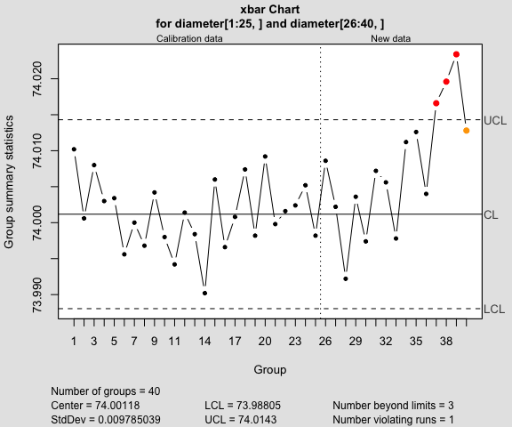

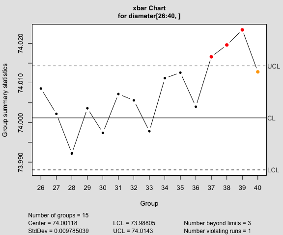

```r
plot(q1, chart.all=FALSE)
```

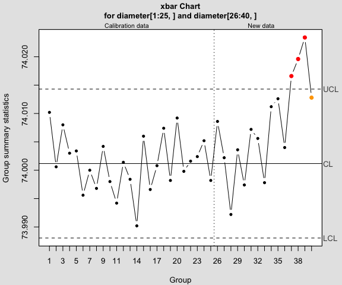

```r
plot(q1, add.stats=FALSE)
```

```r
q1 = qcc(diameter[1:25,], type="xbar", newdata=diameter[26:40,],
         confidence.level=0.99)
```

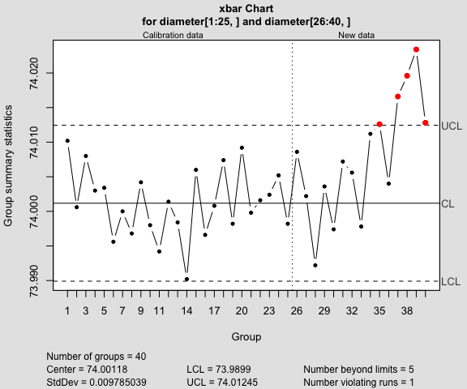

Add warning limits at 2 std. deviations:

```r
q1 = qcc(diameter[1:25,], type="xbar", newdata=diameter[26:40,], plot=FALSE)
(warn.limits = limits.xbar(q1$center, q1$std.dev, q1$sizes, 2))
```

```
##       LCL      UCL
##  73.99242 74.00993
```

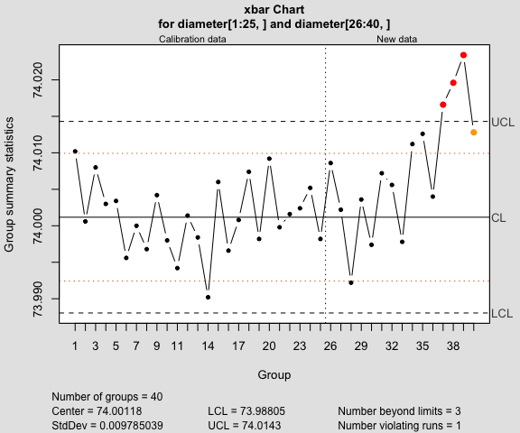

```r
plot(q1, restore.par = FALSE)
abline(h = warn.limits, lty = 3, col = "chocolate")
```

### R chart

```r
q2 = qcc(diameter[1:25,], type="R")
```

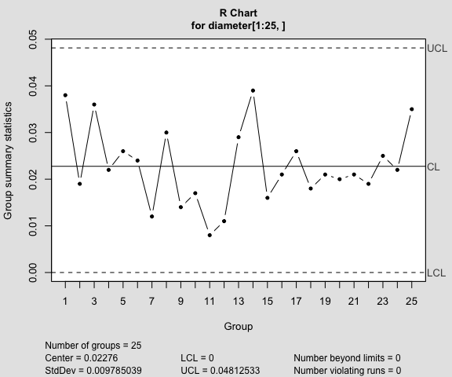

```r
summary(q2)
```

```
##
## Call:
## qcc(data = diameter[1:25, ], type = "R")
##
## R chart for diameter[1:25, ]
##
## Summary of group statistics:
##    Min. 1st Qu.  Median    Mean 3rd Qu.    Max.
## 0.00800 0.01800 0.02100 0.02276 0.02600 0.03900
##
## Group sample size:  5
## Number of groups:  25
## Center of group statistics:  0.02276
## Standard deviation:  0.009785039
##
## Control limits:
##  LCL        UCL
##    0 0.04812533
```

```r
q3 = qcc(diameter[1:25,], type="R", newdata=diameter[26:40,])
```

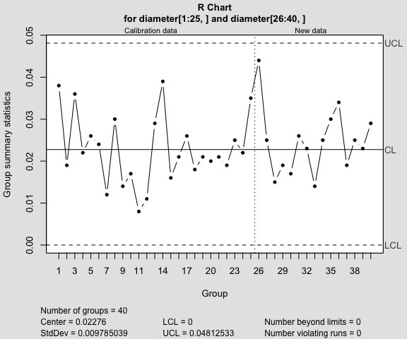

```r
summary(q3)
```

```
##
## Call:
## qcc(data = diameter[1:25, ], type = "R", newdata = diameter[26:40,     ])
##
## R chart for diameter[1:25, ]
##
## Summary of group statistics:
##    Min. 1st Qu.  Median    Mean 3rd Qu.    Max.
## 0.00800 0.01800 0.02100 0.02276 0.02600 0.03900
##
## Group sample size:  5
## Number of groups:  25
## Center of group statistics:  0.02276
## Standard deviation:  0.009785039
##
## Summary of group statistics in diameter[26:40, ]:
##       Min.    1st Qu.     Median       Mean    3rd Qu.       Max.
## 0.01400000 0.01900000 0.02500000 0.02453333 0.02750000 0.04400000
##
## Group sample size:  5
## Number of groups:  15
##
## Control limits:
##  LCL        UCL
##    0 0.04812533
```

### S chart

```r
q4 = qcc(diameter[1:25,], type="S")
```

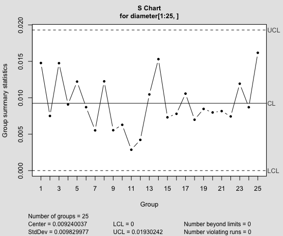

```r
summary(q4)
```

```
##
## Call:
## qcc(data = diameter[1:25, ], type = "S")
##
## S chart for diameter[1:25, ]
##
## Summary of group statistics:
##        Min.     1st Qu.      Median        Mean     3rd Qu.        Max.
## 0.002863564 0.007314369 0.008467585 0.009240037 0.011928956 0.016177144
##
## Group sample size:  5
## Number of groups:  25
## Center of group statistics:  0.009240037
## Standard deviation:  0.009829977
##
## Control limits:
##  LCL        UCL
##    0 0.01930242
```

```r
q5 = qcc(diameter[1:25,], type="S", newdata=diameter[26:40,])
```

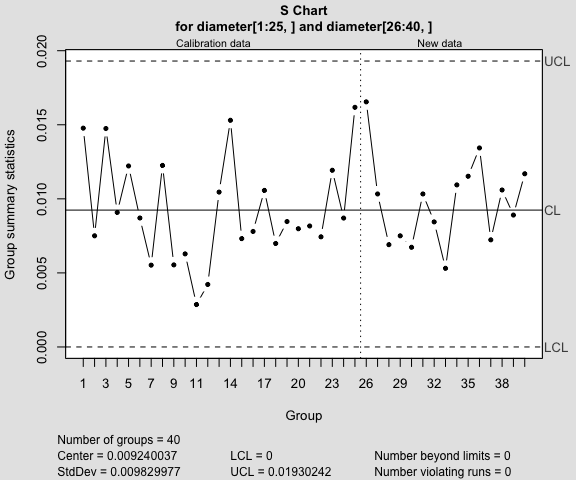

```r
summary(q5)
```

```
##
## Call:
## qcc(data = diameter[1:25, ], type = "S", newdata = diameter[26:40,     ])
##
## S chart for diameter[1:25, ]
##
## Summary of group statistics:
##        Min.     1st Qu.      Median        Mean     3rd Qu.        Max.
## 0.002863564 0.007314369 0.008467585 0.009240037 0.011928956 0.016177144
##
## Group sample size:  5
## Number of groups:  25
## Center of group statistics:  0.009240037
## Standard deviation:  0.009829977
##
## Summary of group statistics in diameter[26:40, ]:
##        Min.     1st Qu.      Median        Mean     3rd Qu.        Max.
## 0.005310367 0.007367603 0.010329569 0.009761757 0.011232319 0.016546903
##
## Group sample size:  5
## Number of groups:  15
##
## Control limits:
##  LCL        UCL
##    0 0.01930242
```

### Variable control limits

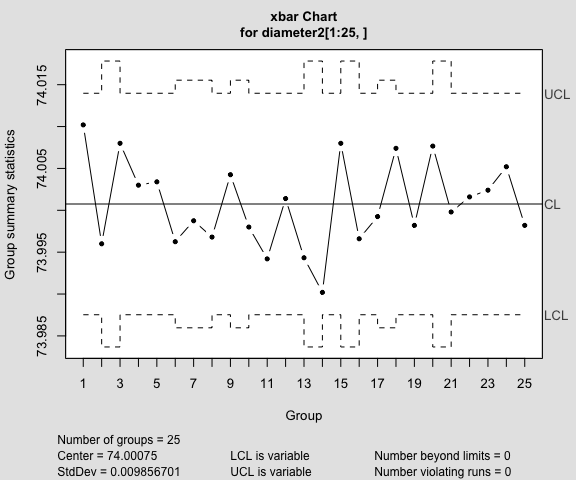

```
##
## Call:
## qcc(data = diameter2[1:25, ], type = "xbar")
##
## xbar chart for diameter2[1:25, ]
##
## Summary of group statistics:
##     Min.  1st Qu.   Median     Mean  3rd Qu.     Max.
## 73.99020 73.99680 73.99980 74.00076 74.00425 74.01020
##
## Summary of group sample sizes:
##   sizes  3 4  5
##   counts 4 4 17
##
## Number of groups:  25
## Center of group statistics:  74.00075
## Standard deviation:  0.009856701
##
## Control limits:
##          LCL      UCL
##     73.98753 74.01398
##     73.98368 74.01782
## ...
##     73.98753 74.01398
```

```r
out = c(9, 10, 30, 35, 45, 64, 65, 74, 75, 85, 99, 100)
diameter2 = with(pistonrings, qcc.groups(diameter[-out], sample[-out]))
summary(qcc(diameter2[1:25,], type="xbar"))
```

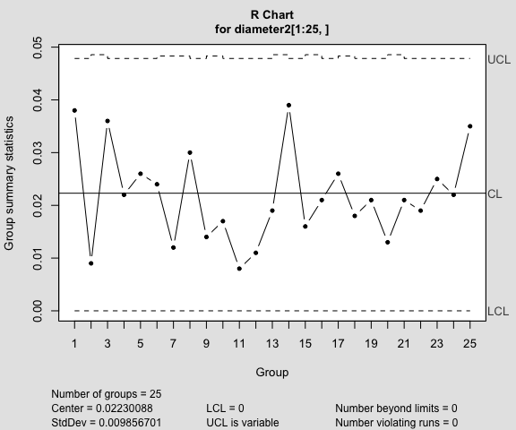

```
##
## Call:
## qcc(data = diameter2[1:25, ], type = "R")
##
## R chart for diameter2[1:25, ]
##
## Summary of group statistics:
##    Min. 1st Qu.  Median    Mean 3rd Qu.    Max.
## 0.00800 0.01600 0.02100 0.02168 0.02600 0.03900
##
## Summary of group sample sizes:
##   sizes  3 4  5
##   counts 4 4 17
##
## Number of groups:  25
## Center of group statistics:  0.02230088
## Standard deviation:  0.009856701
##
## Control limits:
##     LCL        UCL
##       0 0.04785198
##       0 0.04857007
## ...
##       0 0.04785198
```

```r
summary(qcc(diameter2[1:25,], type="R"))
```

### p and np charts

```r
data(orangejuice)
q1 = with(orangejuice,
          qcc(D[trial], sizes=size[trial], type="p"))
```

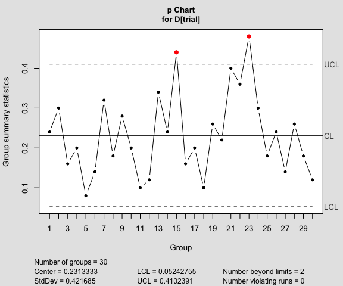

```r
summary(q1)
```

```
##
## Call:
## qcc(data = D[trial], type = "p", sizes = size[trial])
##
## p chart for D[trial]
##
## Summary of group statistics:
##      Min.   1st Qu.    Median      Mean   3rd Qu.      Max.
## 0.0800000 0.1600000 0.2100000 0.2313333 0.2950000 0.4800000
##
## Group sample size:  50
## Number of groups:  30
## Center of group statistics:  0.2313333
## Standard deviation:  0.421685
##
## Control limits:
##            LCL       UCL
##     0.05242755 0.4102391
##     0.05242755 0.4102391
## ...
##     0.05242755 0.4102391
```

```r
q2 = with(orangejuice,
          qcc(D[trial], sizes=size[trial], type="np"))
```

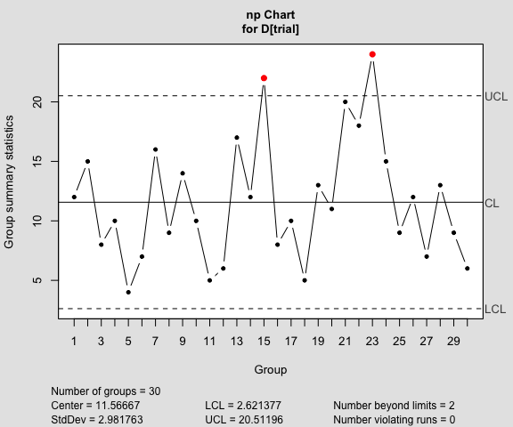

```r
summary(q2)
```

```
##
## Call:
## qcc(data = D[trial], type = "np", sizes = size[trial])
##
## np chart for D[trial]
##
## Summary of group statistics:
##     Min.  1st Qu.   Median     Mean  3rd Qu.     Max.
##  4.00000  8.00000 10.50000 11.56667 14.75000 24.00000
##
## Group sample size:  50
## Number of groups:  30
## Center of group statistics:  11.56667
## Standard deviation:  2.981763
##
## Control limits:
##       LCL      UCL
##  2.621377 20.51196
```

Remove out-of-control points (see `help(orangejuice)` for the reasons):

```r
inc = setdiff(which(orangejuice$trial), c(15,23))
q2 = with(orangejuice,
          qcc(D[inc], sizes=size[inc], type="p",
              newdata=D[!trial], newsizes=size[!trial]))
```

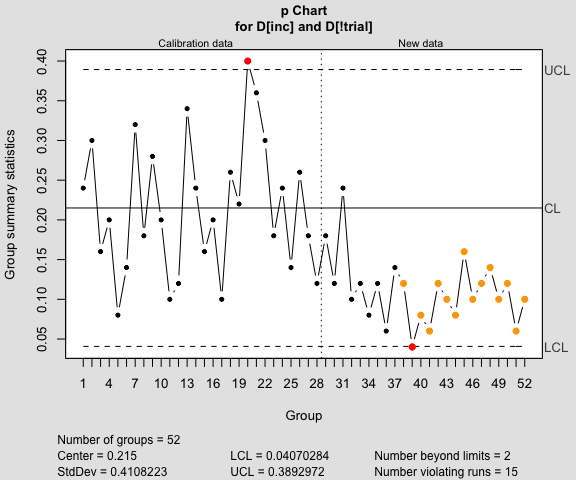

```r
data(orangejuice2)
q1 = with(orangejuice2,
          qcc(D[trial], sizes=size[trial], type="p",
              newdata=D[!trial], newsizes=size[!trial]))
```

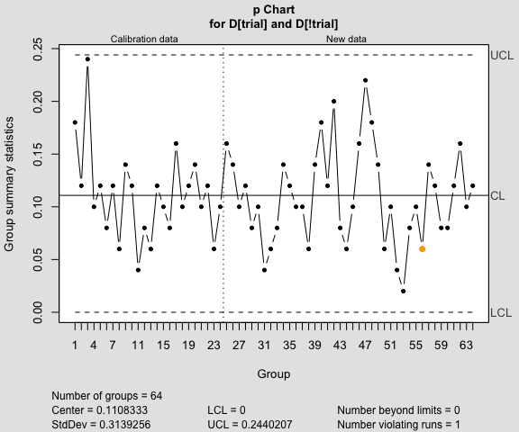

```r
summary(q1)
```

```
##
## Call:
## qcc(data = D[trial], type = "p", sizes = size[trial], newdata = D[!trial],     newsizes = size[!trial])
##
## p chart for D[trial]
##
## Summary of group statistics:
##      Min.   1st Qu.    Median      Mean   3rd Qu.      Max.
## 0.0400000 0.0800000 0.1100000 0.1108333 0.1200000 0.2400000
##
## Group sample size:  50
## Number of groups:  24
## Center of group statistics:  0.1108333
## Standard deviation:  0.3139256
##
## Summary of group statistics in D[!trial]:
##    Min. 1st Qu.  Median    Mean 3rd Qu.    Max.
##   0.020   0.080   0.100   0.109   0.140   0.220
##
## Group sample size:  50
## Number of groups:  40
##
## Control limits:
##     LCL       UCL
##       0 0.2440207
##       0 0.2440207
## ...
##       0 0.2440207
```

### c and u charts

```r
data(circuit)
q1 = with(circuit,
          qcc(x[trial], sizes=size[trial], type="c"))
```

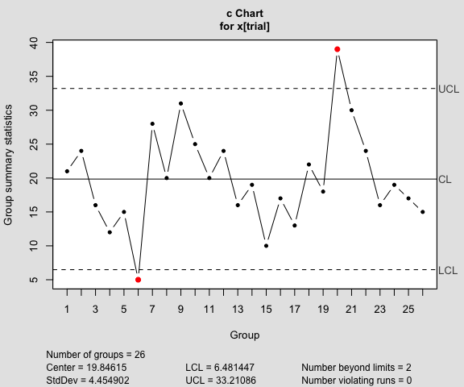

```r
summary(q1)
```

```
##
## Call:
## qcc(data = x[trial], type = "c", sizes = size[trial])
##
## c chart for x[trial]
##
## Summary of group statistics:
##     Min.  1st Qu.   Median     Mean  3rd Qu.     Max.
##  5.00000 16.00000 19.00000 19.84615 24.00000 39.00000
##
## Group sample size:  100
## Number of groups:  26
## Center of group statistics:  19.84615
## Standard deviation:  4.454902
##
## Control limits:
##       LCL      UCL
##  6.481447 33.21086
```

Remove out-of-control points (see `help(circuit)` for the reasons)

```r
inc = setdiff(which(circuit$trial), c(6,20))
q2 = with(circuit,
          qcc(x[inc], sizes=size[inc], type="c", labels=inc,
              newdata=x[!trial], newsizes=size[!trial], newlabels=which(!trial)))
```

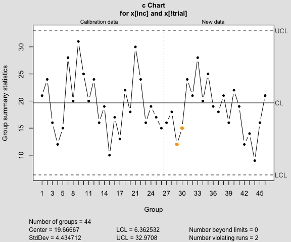

```r
summary(q2)
```

```
##
## Call:
## qcc(data = x[inc], type = "c", sizes = size[inc], labels = inc,     newdata = x[!trial], newsizes = size[!trial], newlabels = which(!trial))
##
## c chart for x[inc]
##
## Summary of group statistics:
##     Min.  1st Qu.   Median     Mean  3rd Qu.     Max.
## 10.00000 16.00000 19.00000 19.66667 24.00000 31.00000
##
## Group sample size:  100
## Number of groups:  24
## Center of group statistics:  19.66667
## Standard deviation:  4.434712
##
## Summary of group statistics in x[!trial]:
##    Min. 1st Qu.  Median    Mean 3rd Qu.    Max.
##    9.00   15.75   18.50   18.30   21.00   28.00
##
## Group sample size:  100
## Number of groups:  20
##
## Control limits:
##       LCL     UCL
##  6.362532 32.9708
```

```r
q3 = with(circuit,
          qcc(x[inc], sizes=size[inc], type="u", labels=inc,
              newdata=x[!trial], newsizes=size[!trial], newlabels=which(!trial)))
```

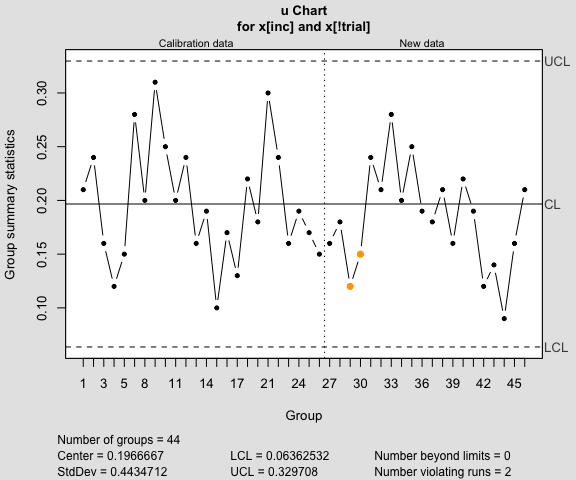

```r
summary(q3)
```

```
##
## Call:
## qcc(data = x[inc], type = "u", sizes = size[inc], labels = inc,     newdata = x[!trial], newsizes = size[!trial], newlabels = which(!trial))
##
## u chart for x[inc]
##
## Summary of group statistics:
##      Min.   1st Qu.    Median      Mean   3rd Qu.      Max.
## 0.1000000 0.1600000 0.1900000 0.1966667 0.2400000 0.3100000
##
## Group sample size:  100
## Number of groups:  24
## Center of group statistics:  0.1966667
## Standard deviation:  0.4434712
##
## Summary of group statistics in x[!trial]:
##    Min. 1st Qu.  Median    Mean 3rd Qu.    Max.
##  0.0900  0.1575  0.1850  0.1830  0.2100  0.2800
##
## Group sample size:  100
## Number of groups:  20
##
## Control limits:
##         LCL      UCL
##  0.06362532 0.329708
```

```r
data(pcmanufact)
q1 = with(pcmanufact,
          qcc(x, sizes=size, type="u"))
```

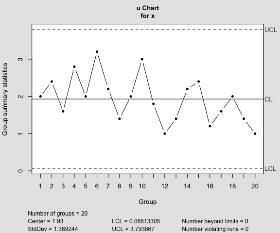

```r
summary(q1)
```

```
##
## Call:
## qcc(data = x, type = "u", sizes = size)
##
## u chart for x
##
## Summary of group statistics:
##    Min. 1st Qu.  Median    Mean 3rd Qu.    Max.
##    1.00    1.40    2.00    1.93    2.25    3.20
##
## Group sample size:  5
## Number of groups:  20
## Center of group statistics:  1.93
## Standard deviation:  1.389244
##
## Control limits:
##         LCL      UCL
##  0.06613305 3.793867
```

### Continuous one-at-time data

```r
# viscosity data (Montgomery, pag. 242)
x = c(33.75, 33.05, 34, 33.81, 33.46, 34.02, 33.68, 33.27, 33.49, 33.20,
       33.62, 33.00, 33.54, 33.12, 33.84)
q1 = qcc(x, type="xbar.one")
```

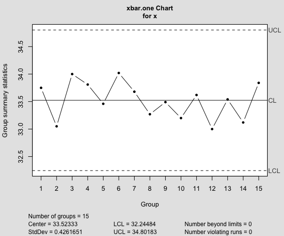

```r
summary(q1)
```

```
##
## Call:
## qcc(data = x, type = "xbar.one")
##
## xbar.one chart for x
##
## Summary of group statistics:
##     Min.  1st Qu.   Median     Mean  3rd Qu.     Max.
## 33.00000 33.23500 33.54000 33.52333 33.78000 34.02000
##
## Group sample size:  1
## Number of groups:  15
## Center of group statistics:  33.52333
## Standard deviation:  0.4261651
##
## Control limits:
##       LCL      UCL
##  32.24484 34.80183
```

```r
q2 = qcc(x, type="xbar.one", std.dev = "SD")
```

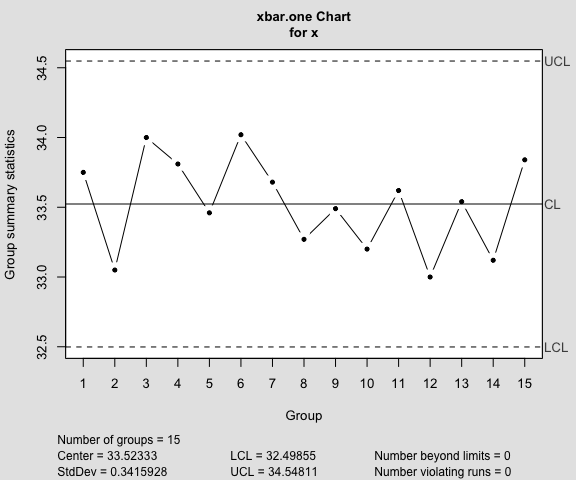

```r
summary(q2)
```

```
##
## Call:
## qcc(data = x, type = "xbar.one", std.dev = "SD")
##
## xbar.one chart for x
##
## Summary of group statistics:
##     Min.  1st Qu.   Median     Mean  3rd Qu.     Max.
## 33.00000 33.23500 33.54000 33.52333 33.78000 34.02000
##
## Group sample size:  1
## Number of groups:  15
## Center of group statistics:  33.52333
## Standard deviation:  0.3415928
##
## Control limits:
##       LCL      UCL
##  32.49855 34.54811
```

### Standardized p chart

In this example we show how to extend the package by defining a new control chart, i.e. a standardized p chart (`type = "p.std"`).

Function to compute group statistics and center:

```r
stats.p.std = function(data, sizes)
{
  data = as.vector(data)
  sizes = as.vector(sizes)
  pbar = sum(data)/sum(sizes)
  z = (data/sizes - pbar)/sqrt(pbar*(1-pbar)/sizes)
  list(statistics = z, center = 0)
}
```

Function to compute within-group standard deviation:

```r
sd.p.std = function(data, sizes, ...) { return(1) }
```

Function to compute control limits based on normal approximation:

```r
limits.p.std = function(center, std.dev, sizes, conf)
{
  if(conf >= 1)
    { lcl = -conf
      ucl = +conf
  }
  else
    { if(conf > 0 & conf < 1)
        { nsigmas = qnorm(1 - (1 - conf)/2)
          lcl = -nsigmas
          ucl = +nsigmas }
      else stop("invalid 'conf' argument.")
  }
  limits = matrix(c(lcl, ucl), ncol = 2)
  rownames(limits) = rep("", length = nrow(limits))
  colnames(limits) = c("LCL", "UCL")
  return(limits)
}
```

Example with simulated data:

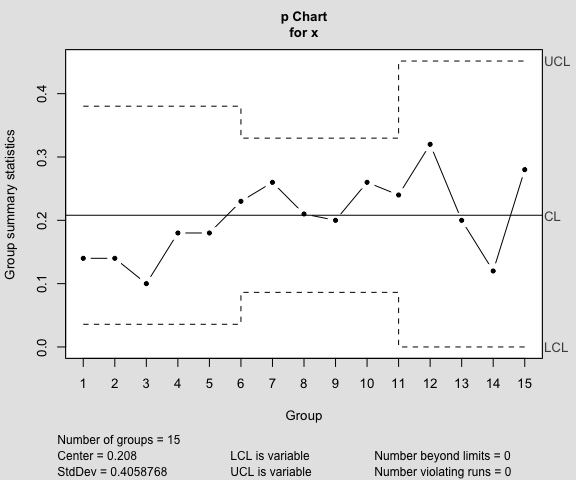

```
##
## Call:
## qcc(data = x, type = "p", sizes = n)
##
## p chart for x
##
## Summary of group statistics:
##    Min. 1st Qu.  Median    Mean 3rd Qu.    Max.
##   0.100   0.160   0.200   0.204   0.250   0.320
##
## Summary of group sample sizes:
##   sizes  25 50 100
##   counts  5  5   5
##
## Number of groups:  15
## Center of group statistics:  0.208
## Standard deviation:  0.4058768
##
## Control limits:
##            LCL       UCL
##     0.03580105 0.3801990
##     0.03580105 0.3801990
## ...
##     0.00000000 0.4515261
```

```r
# set unequal sample sizes
n = c(rep(50,5), rep(100,5), rep(25, 5))
# generate randomly the number of successes
x = rbinom(length(n), n, 0.2)
# plot the control chart with variable limits
summary(qcc(x, type="p", size=n))
```

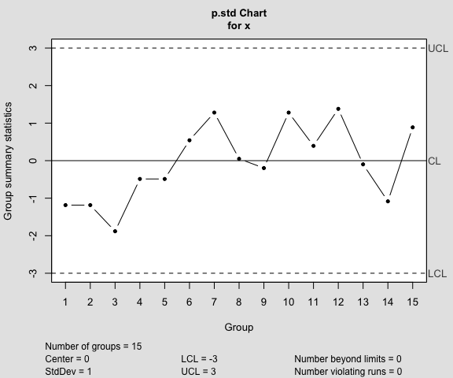

```
##
## Call:
## qcc(data = x, type = "p.std", sizes = n)
##
## p.std chart for x
##
## Summary of group statistics:
##       Min.    1st Qu.     Median       Mean    3rd Qu.       Max.
## -1.8815445 -0.7859403 -0.0985521 -0.0527780  0.7145025  1.3797289
##
## Summary of group sample sizes:
##   sizes  25 50 100
##   counts  5  5   5
##
## Number of groups:  15
## Center of group statistics:  0
## Standard deviation:  1
##
## Control limits:
##  LCL UCL
##   -3   3
```

```r
# plot the standardized control chart
summary(qcc(x, type="p.std", size=n))
```

## Operating Characteristic Curves

An operating characteristic curve graphically provides information about the probability of not detecting a shift in the process. The function `oc.curves()` is a generic function which calls the proper function depending on the type of input `'qcc'` object.

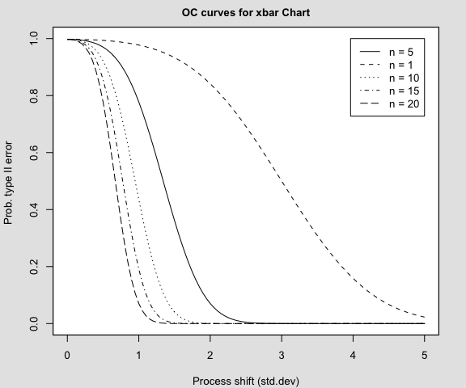

```r
data(pistonrings)
diameter = with(pistonrings, qcc.groups(diameter, sample))
q = qcc(diameter, type="xbar", nsigmas=3, plot=FALSE)
beta = oc.curves.xbar(q)
```

```r
print(round(beta, digits=4))
```

```
##                sample size
## shift (std.dev)    n=5    n=1   n=10   n=15   n=20
##            0    0.9973 0.9973 0.9973 0.9973 0.9973
##            0.05 0.9971 0.9973 0.9970 0.9968 0.9966
##            0.1  0.9966 0.9972 0.9959 0.9952 0.9944
##            0.15 0.9957 0.9970 0.9940 0.9920 0.9900
##            0.2  0.9944 0.9968 0.9909 0.9869 0.9823
##            0.25 0.9925 0.9964 0.9864 0.9789 0.9701
##            0.3  0.9900 0.9960 0.9798 0.9670 0.9514
##            0.35 0.9866 0.9956 0.9708 0.9500 0.9243
##            0.4  0.9823 0.9950 0.9586 0.9266 0.8871
##            0.45 0.9769 0.9943 0.9426 0.8957 0.8383
##            0.5  0.9701 0.9936 0.9220 0.8562 0.7775
##            0.55 0.9616 0.9927 0.8963 0.8078 0.7055
##            0.6  0.9514 0.9916 0.8649 0.7505 0.6243
##            0.65 0.9390 0.9905 0.8275 0.6853 0.5371
##            0.7  0.9243 0.9892 0.7842 0.6137 0.4481
##            0.75 0.9071 0.9877 0.7351 0.5379 0.3616
##            0.8  0.8871 0.9860 0.6809 0.4608 0.2817
##            0.85 0.8642 0.9842 0.6225 0.3851 0.2115
##            0.9  0.8383 0.9821 0.5612 0.3136 0.1527
##            0.95 0.8094 0.9798 0.4983 0.2485 0.1059
##            1    0.7775 0.9772 0.4355 0.1913 0.0705
##            1.05 0.7428 0.9744 0.3743 0.1431 0.0450
##            1.1  0.7055 0.9713 0.3161 0.1038 0.0275
##            1.15 0.6659 0.9678 0.2622 0.0730 0.0161
##            1.2  0.6243 0.9641 0.2134 0.0497 0.0090
##            1.25 0.5812 0.9599 0.1703 0.0328 0.0048
##            1.3  0.5371 0.9554 0.1333 0.0209 0.0024
##            1.35 0.4925 0.9505 0.1022 0.0129 0.0012
##            1.4  0.4481 0.9452 0.0768 0.0077 0.0006
##            1.45 0.4043 0.9394 0.0564 0.0045 0.0002
##            1.5  0.3616 0.9332 0.0406 0.0025 0.0001
##            1.55 0.3206 0.9265 0.0286 0.0013 0.0000
##            1.6  0.2817 0.9192 0.0197 0.0007 0.0000
##            1.65 0.2453 0.9115 0.0133 0.0003 0.0000
##            1.7  0.2115 0.9032 0.0088 0.0002 0.0000
##            1.75 0.1806 0.8943 0.0056 0.0001 0.0000
##            1.8  0.1527 0.8849 0.0036 0.0000 0.0000
##            1.85 0.1278 0.8749 0.0022 0.0000 0.0000
```

[output cut: 48 more lines]

```
##            4.3  0.0000 0.0968 0.0000 0.0000 0.0000
##            4.35 0.0000 0.0885 0.0000 0.0000 0.0000
##            4.4  0.0000 0.0808 0.0000 0.0000 0.0000
##            4.45 0.0000 0.0735 0.0000 0.0000 0.0000
##            4.5  0.0000 0.0668 0.0000 0.0000 0.0000
##            4.55 0.0000 0.0606 0.0000 0.0000 0.0000
##            4.6  0.0000 0.0548 0.0000 0.0000 0.0000
##            4.65 0.0000 0.0495 0.0000 0.0000 0.0000
##            4.7  0.0000 0.0446 0.0000 0.0000 0.0000
##            4.75 0.0000 0.0401 0.0000 0.0000 0.0000
##            4.8  0.0000 0.0359 0.0000 0.0000 0.0000
##            4.85 0.0000 0.0322 0.0000 0.0000 0.0000
##            4.9  0.0000 0.0287 0.0000 0.0000 0.0000
##            4.95 0.0000 0.0256 0.0000 0.0000 0.0000
##            5    0.0000 0.0228 0.0000 0.0000 0.0000
```

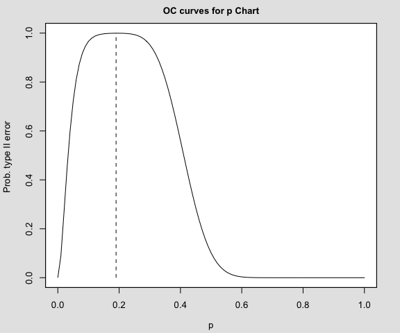

```r
data(orangejuice)
q = with(orangejuice, qcc(D[trial], sizes=size[trial], type="p", plot=FALSE))
beta = oc.curves(q)
```

```r
print(round(beta, digits=4))
```

```
##      0   0.01   0.02   0.03   0.04   0.05   0.06   0.07   0.08   0.09
## 0.0000 0.0894 0.2642 0.4447 0.5995 0.7206 0.8100 0.8735 0.9173 0.9468
##    0.1   0.11   0.12   0.13   0.14   0.15   0.16   0.17   0.18   0.19
## 0.9662 0.9788 0.9869 0.9920 0.9951 0.9971 0.9983 0.9990 0.9993 0.9995
##    0.2   0.21   0.22   0.23   0.24   0.25   0.26   0.27   0.28   0.29
## 0.9995 0.9993 0.9987 0.9978 0.9962 0.9937 0.9900 0.9845 0.9768 0.9662
##    0.3   0.31   0.32   0.33   0.34   0.35   0.36   0.37   0.38   0.39
## 0.9522 0.9343 0.9118 0.8844 0.8518 0.8139 0.7711 0.7236 0.6722 0.6176
##    0.4   0.41   0.42   0.43   0.44   0.45   0.46   0.47   0.48   0.49
## 0.5610 0.5035 0.4461 0.3901 0.3365 0.2862 0.2398 0.1980 0.1609 0.1287
##    0.5   0.51   0.52   0.53   0.54   0.55   0.56   0.57   0.58   0.59
## 0.1013 0.0784 0.0596 0.0446 0.0327 0.0235 0.0166 0.0115 0.0078 0.0052
##    0.6   0.61   0.62   0.63   0.64   0.65   0.66   0.67   0.68   0.69
## 0.0034 0.0021 0.0013 0.0008 0.0005 0.0003 0.0002 0.0001 0.0000 0.0000
##    0.7   0.71   0.72   0.73   0.74   0.75   0.76   0.77   0.78   0.79
## 0.0000 0.0000 0.0000 0.0000 0.0000 0.0000 0.0000 0.0000 0.0000 0.0000
##    0.8   0.81   0.82   0.83   0.84   0.85   0.86   0.87   0.88   0.89
## 0.0000 0.0000 0.0000 0.0000 0.0000 0.0000 0.0000 0.0000 0.0000 0.0000
##    0.9   0.91   0.92   0.93   0.94   0.95   0.96   0.97   0.98   0.99
## 0.0000 0.0000 0.0000 0.0000 0.0000 0.0000 0.0000 0.0000 0.0000 0.0000
##      1
## 0.0000
```

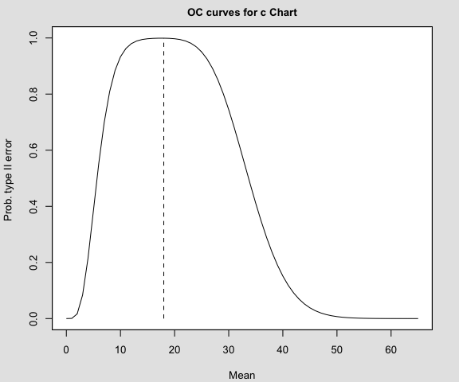

```r
data(circuit)
q = with(circuit, qcc(x[trial], sizes=size[trial], type="c", plot=FALSE))
beta = oc.curves(q)
```

```r
print(round(beta, digits=4))
```

```
##      0      1      2      3      4      5      6      7      8      9
## 0.0000 0.0006 0.0166 0.0839 0.2149 0.3840 0.5543 0.6993 0.8088 0.8843
##     10     11     12     13     14     15     16     17     18     19
## 0.9329 0.9625 0.9797 0.9893 0.9945 0.9972 0.9986 0.9991 0.9992 0.9986
##     20     21     22     23     24     25     26     27     28     29
## 0.9972 0.9945 0.9895 0.9813 0.9686 0.9502 0.9249 0.8918 0.8505 0.8011
##     30     31     32     33     34     35     36     37     38     39
## 0.7444 0.6818 0.6150 0.5461 0.4772 0.4102 0.3470 0.2888 0.2365 0.1907
##     40     41     42     43     44     45     46     47     48     49
## 0.1514 0.1184 0.0912 0.0693 0.0519 0.0383 0.0280 0.0201 0.0143 0.0101
##     50     51     52     53     54     55     56     57     58     59
## 0.0070 0.0048 0.0033 0.0022 0.0015 0.0010 0.0006 0.0004 0.0003 0.0002
##     60     61     62     63     64     65
## 0.0001 0.0001 0.0000 0.0000 0.0000 0.0000
```

## Cusum chart

```r
data(pistonrings)
diameter = with(pistonrings, qcc.groups(diameter, sample))

q1 = cusum(diameter[1:25,], decision.interval = 4, se.shift = 1)
```

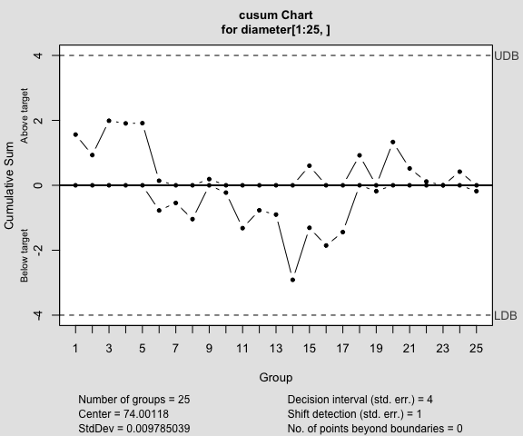

```r
summary(q1)
```

```
##
## Call:
## cusum(data = diameter[1:25, ], decision.interval = 4, se.shift = 1)
##
## cusum chart for diameter[1:25, ]
##
## Summary of group statistics:
##    Min. 1st Qu.  Median    Mean 3rd Qu.    Max.
##   73.99   74.00   74.00   74.00   74.00   74.01
##
## Group sample size:  5
## Number of groups:  25
## Center of group statistics:  74.00118
## Standard deviation:  0.009785039
##
## Decision interval (std.err.): 4
## Shift detection  (std. err.): 1
```

```r
q2 = cusum(diameter[1:25,], newdata=diameter[26:40,])
```

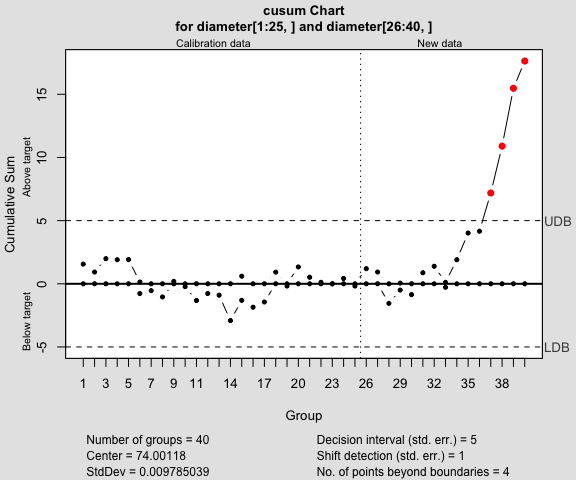

```r
summary(q2)
```

```
##
## Call:
## cusum(data = diameter[1:25, ], newdata = diameter[26:40, ])
##
## cusum chart for diameter[1:25, ]
##
## Summary of group statistics:
##    Min. 1st Qu.  Median    Mean 3rd Qu.    Max.
##   73.99   74.00   74.00   74.00   74.00   74.01
##
## Group sample size:  5
## Number of groups:  25
## Center of group statistics:  74.00118
## Standard deviation:  0.009785039
##
## Summary of group statistics in diameter[26:40, ]:
##     Min.  1st Qu.   Median     Mean  3rd Qu.     Max.
## 73.99220 74.00290 74.00720 74.00765 74.01270 74.02340
##
## Group sample size:  5
## Number of groups:  15
##
## Decision interval (std.err.): 5
## Shift detection  (std. err.): 1
```

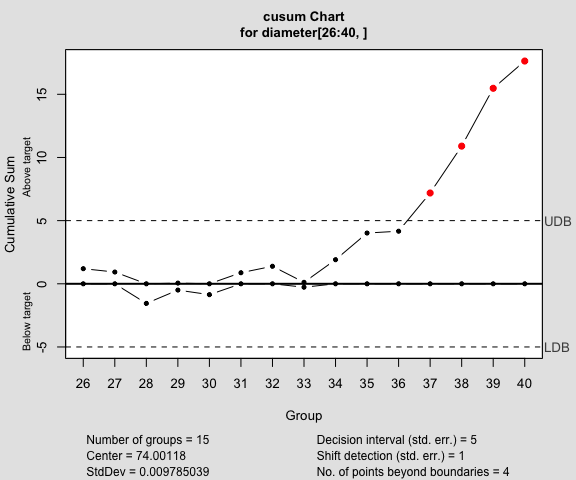

```r
plot(q2, chart.all=FALSE)
```

## EWMA

```r
data(pistonrings)
diameter = with(pistonrings, qcc.groups(diameter, sample))

q1 = ewma(diameter[1:25,], lambda=0.2, nsigmas=3)
```

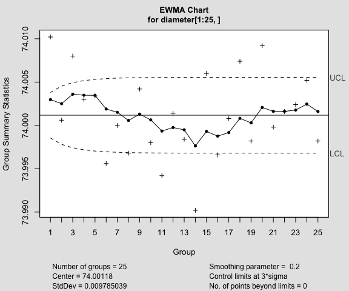

```r
summary(q1)
```

```
##
## Call:
## ewma(data = diameter[1:25, ], lambda = 0.2, nsigmas = 3)
##
## ewma chart for diameter[1:25, ]
##
## Summary of group statistics:
##     Min.  1st Qu.   Median     Mean  3rd Qu.     Max.
## 73.99020 73.99820 74.00080 74.00118 74.00420 74.01020
##
## Group sample size:  5
## Number of groups:  25
## Center of group statistics:  74.00118
## Standard deviation:  0.009785039
##
## Smoothing parameter: 0.2
## Control limits:
##          LCL      UCL
## 1   73.99855 74.00380
## 2   73.99781 74.00454
## ...
## 25  73.99680 74.00555
```

```r
q2 =  ewma(diameter[1:25,], lambda=0.2, nsigmas=2.7,
            newdata=diameter[26:40,])
```

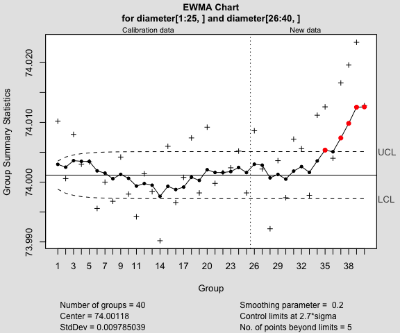

```r
summary(q2)
```

```
##
## Call:
## ewma(data = diameter[1:25, ], lambda = 0.2, nsigmas = 2.7, newdata = diameter[26:40,     ])
##
## ewma chart for diameter[1:25, ]
##
## Summary of group statistics:
##     Min.  1st Qu.   Median     Mean  3rd Qu.     Max.
## 73.99020 73.99820 74.00080 74.00118 74.00420 74.01020
##
## Group sample size:  5
## Number of groups:  25
## Center of group statistics:  74.00118
## Standard deviation:  0.009785039
##
## Summary of group statistics in diameter[26:40, ]:
##     Min.  1st Qu.   Median     Mean  3rd Qu.     Max.
## 73.99220 74.00290 74.00720 74.00765 74.01270 74.02340
##
## Group sample size:  5
## Number of groups:  15
##
## Smoothing parameter: 0.2
## Control limits:
##          LCL      UCL
## 1   73.99881 74.00354
## 2   73.99815 74.00420
## ...
## 40  73.99724 74.00511
```

```r
x = c(33.75, 33.05, 34, 33.81, 33.46, 34.02, 33.68, 33.27,
       33.49, 33.20, 33.62, 33.00, 33.54, 33.12, 33.84)
q3 =  ewma(x, lambda=0.2, nsigmas=2.7)
```

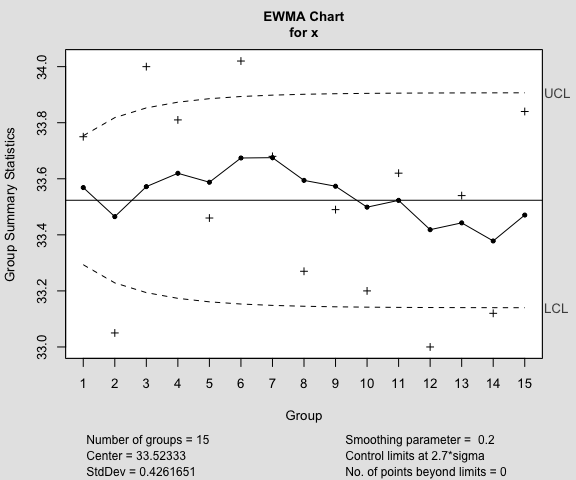

```r
summary(q3)
```

```
##
## Call:
## ewma(data = x, lambda = 0.2, nsigmas = 2.7)
##
## ewma chart for x
##
## Summary of group statistics:
##     Min.  1st Qu.   Median     Mean  3rd Qu.     Max.
## 33.00000 33.23500 33.54000 33.52333 33.78000 34.02000
##
## Group sample size:  1
## Number of groups:  15
## Center of group statistics:  33.52333
## Standard deviation:  0.4261651
##
## Smoothing parameter: 0.2
## Control limits:
##            LCL      UCL
## [1,]  33.29320 33.75346
## [2,]  33.22862 33.81804
## ...
## [15,] 33.14002 33.90664
```